# Maximum Likelihood Estimation

Tom Fletcher

January 16, 2018

The purpose of these notes is to review the definition of a *maximum likelihood estimate* (MLE), and show that the sample mean is the MLE of the $\mu$ parameter in a Gaussian. For more details about MLEs, see the Wikipedia article:

https://en.wikipedia.org/wiki/Maximum_likelihood

Consider a random sample $X_1, X_2, \ldots, X_n$ coming from a distribution with parameter $\theta$ (for example, they could be from a Gaussian distribution with parameter $\mu$). Remember the terminology “random sample” means that $X_i$ random variables are independent and identically distributed (i.i.d.). Furthermore, let’s assume that each $X_i$ has a probability density function $p_{X_i}(x; \theta)$. Given a realization of our random sample, $x_1, x_2, \ldots, x_n$, (remember, these are the actual *numbers* that we have observed), we define the *likelihood function* $\mathcal{L}(\theta)$ as follows:
$$\begin{aligned}
\mathcal{L}(\theta) &= p_{X_1, \ldots, X_n}(x_1, x_2, \ldots, x_n; \theta),
& \text{}\\
&= \prod_{i=1}^n p_{X_i}(x_i; \theta),
&\text{using independence of the $X_i$.}\\
\end{aligned}$$
Here, $p_{X_1, \ldots, X_n}$ is the joint pdf for all of the $X_i$ variables. This pdf depends on the value of the parameter $\theta$ for the distribution, so that is in the notation after the semicolon. Notice an important point, we are treating the $x_i$ as constants (they are the data that we’ve observed) and $\mathcal{L}$ is a function of $\theta$. Maximum likelihood now says that we want to maximize this likelihood function as a function of $\theta$.

Now, let’s work this out for the Gaussian case, i.e., let $X_1, X_2, \ldots, X_n \sim N(\mu, \sigma^2)$. We will focus only on the MLE of the $\mu$ parameter, essentially treating $\sigma^2$ as a known constant for simplicity of the example. The likelihood function looks like this:
$$\begin{aligned}
\mathcal{L}(\mu) &= p_{X_1, \ldots, X_n}(x_1, x_2, \ldots, x_n; \mu),
& \text{}\\
%
&= \prod_{i=1}^n p_{X_i}(x_i; \theta),
&\text{using independence of the $X_i$,}\\
%
&= \prod_{i=1}^n \frac{1}{\sqrt{2 \pi}}
\exp\left(-\frac{1}{2\sigma^2} (x_i - \mu)^2\right),
&\text{using Gaussian pdf for each $X_i$,}\\
%
&= \left(\frac{1}{\sqrt{2 \pi} \sigma}\right)^n
\exp\left(-\frac{1}{2\sigma^2} \sum_{i=1}^n (x_i - \mu)^2\right),
&\text{product turns into a sum inside $\exp$.}
\end{aligned}$$

To maximize this function, it is easier to think about maximizing it’s natural log. We can do this because $\ln$ is a monotonically increasing function, so the value of $\mu$ that maximizes $\mathcal{L}$ also maximizes $\ln \mathcal{L}$. So, the *log likelihood function* is defined as
$$\ell(\mu) = \ln \mathcal{L}(\mu)
= -\frac{1}{2\sigma^2} \sum_{i=1}^n (x_i - \mu)^2 + C,$$
where $C$ is a constant in $\mu$ (we don’t need it to maximize $\ell$). Now, defining our estimate of $\mu$ to maximize the log likelihood, we get
$$\hat{\mu} = \arg \max_{\mu}\; \ell(\mu)
= \arg \min_{\mu} \sum_{i=1}^n (x_i - \mu)^2.$$
Notice we changed the sign in the last equality, and this changes us from a max to a min problem. This is called *least squares*, as we are minimizing the sum-of-squared differences from the $\mu$ to our data $x_i$. We can solve this maximization problem exactly using the fact (from calculus) that the derivative of $\ell$ with respect to $\mu$ will be zero at a maxima. We get
$$0 = \frac{d}{d\mu} \ell(\mu) = \frac{d}{d\mu} \sum_{i=1}^n (x_i - \mu)^2 =
2n\mu - 2\sum_{i=1}^n x_i.$$
Solving for $\mu$, we get the sample mean as the MLE:
$$\hat{\mu} = \frac{1}{n} \sum_{i=1}^n x_i.$$

Here is some R code demonstrating the above MLE of the mean of a Gaussian. First, we generate a random sample from a normal distribution.

```r
## Start by generating a sample from a normal distribtion
n = 20     ## Number of data points to generate
mu = 3     ## Mean of Gaussian
sigma = 2  ## Standard deviation of Gaussian

## rnorm function in R generates Gaussian (pseudo)random variables
x = rnorm(n, mean = mu, sd = sigma)
```

Next, we plot the likelihood functions, $p(x_i | \mu)$, for each of the points separately.

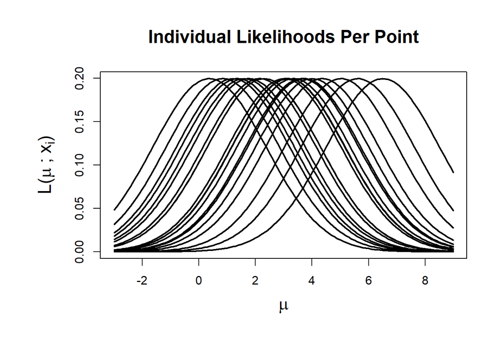

```r
## This sequence is for the x-axis in our plots
t = seq(mu - 3*sigma, mu + 3*sigma, sigma/20)

## This sets the plot margins
par(mai=c(1.4, 1.4, 1, 0.5))

## Plot individual likelihoods for each data point
## The dnorm function evaluates the pdf of the Gaussian
plot(t, dnorm(t, mean = x[1], sd = sigma), type='l', lwd = 2,
     main = "Individual Likelihoods Per Point",
     ylab = expression(paste("L(", mu, " ; x"[i], ")")),
     xlab = expression(mu), cex.lab = 1.5, cex.main = 1.5)
for(i in 2:n)
  lines(t, dnorm(t, x[i], sigma), lwd = 2)
```

Next, we plot the likelihood function for all of the data, and draw a vertical line at the sample mean of the data to see that it is indeed at the maximum.

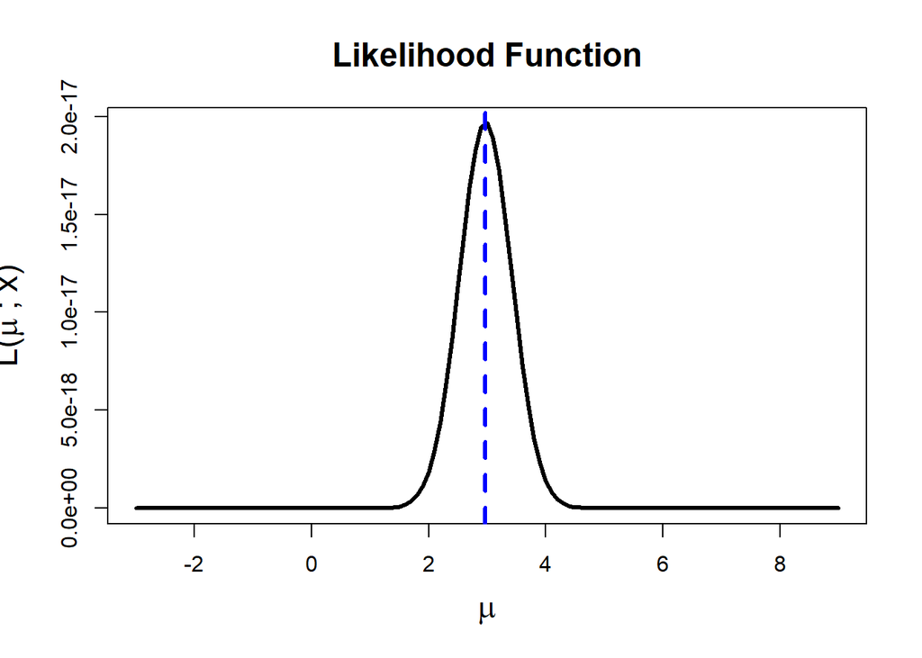

```r
## Compute the likelihood function for all of the data
lik = 1
for(i in 1:n)
  lik = lik * dnorm(t, x[i], sigma)

## Plot the likelihood
## NOTE: This will not work if you set n large enough!
plot(t, lik, type='l', lwd = 3,
     main = "Likelihood Function",
     ylab = expression(paste("L(", mu, " ; x)")),
     xlab = expression(mu), cex.lab = 1.5, cex.main = 1.5)

## Draw a vertical line at the mean value of the data
abline(v = mean(x), col='blue', lwd = 3, lty = 2)
```

Finally, we plot the log-likelihood function (which is just a quadratic).

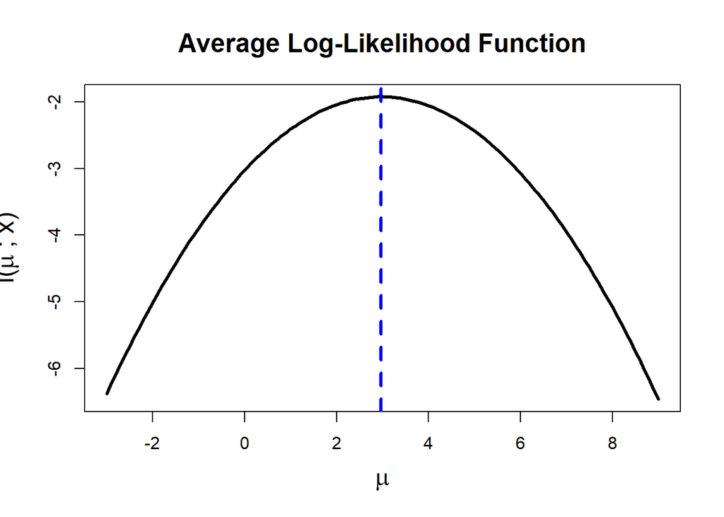

```r
## Now compute the average log likelihood of the data and plot it
log.lik = 0
for(i in 1:n)
  log.lik = log.lik + (1/n) * log(dnorm(t, x[i], sigma))

plot(t, log.lik, type='l', lwd = 3,
     main = "Average Log-Likelihood Function",
     ylab = expression(paste("l(", mu, " ; x)")),
     xlab = expression(mu), cex.lab = 1.5, cex.main = 1.5)
abline(v = mean(x), col='blue', lwd = 3, lty = 2)
```